# Week 4 Lab Exercise - KEY

Prof. Amanda D. Perez, PhD

# Hotel bookings - factors

```r
library(tidyverse)
library(skimr)
library(scales)
library(forcats)
library(viridis)
```

```r
# From TidyTuesday: https://github.com/rfordatascience/tidytuesday/blob/master/data/2020/2020-02-11/readme.md
hotels <- read_csv("https://raw.githubusercontent.com/rfordatascience/tidytuesday/master/data/2020/2020-02-11/hotels.csv") %>%
  sample_n(1000)
```

First, knit the document and view the following visualization:

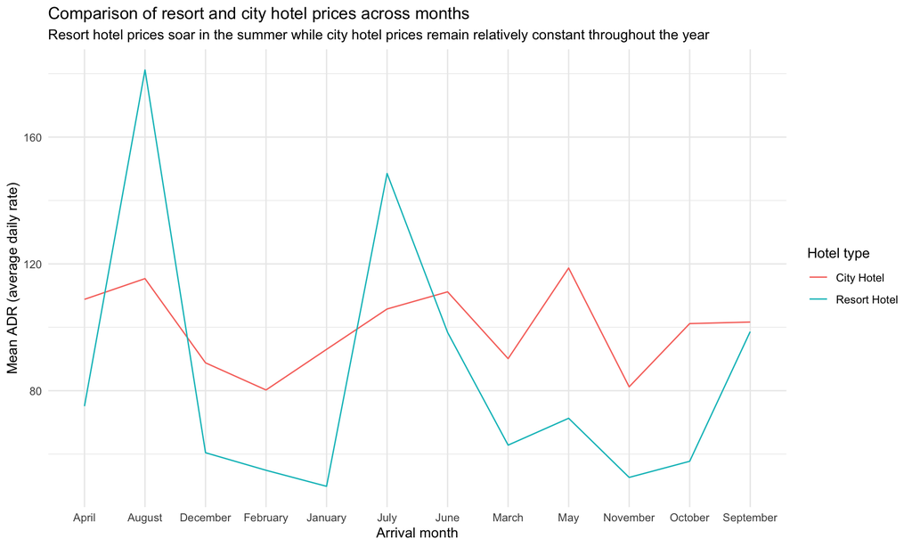

```r
hotels %>%
  group_by(hotel, arrival_date_month) %>%   # group by hotel type and arrival month
  summarise(mean_adr = mean(adr)) %>%       # calculate mean adr for each group
  ggplot(aes(
    x = arrival_date_month,                 # x-axis = arrival_date_month
    y = mean_adr,                           # y-axis = mean_adr calculated above
    group = hotel,                          # group lines by hotel type
    color = hotel)                          # and color by hotel type
    ) +
  geom_line() +                             # use lines to represent data
  theme_minimal() +                         # use a minimal theme
  labs(x = "Arrival month",                 # customize labels
       y = "Mean ADR (average daily rate)",
       title = "Comparison of resort and city hotel prices across months",
       subtitle = "Resort hotel prices soar in the summer while city hotel prices remain relatively constant throughout the year",
       color = "Hotel type")
```

How are the months ordered?

**Alphabetically**

What would be a better order?

**Chronologically from January - December.**

## Your Turn:

Below I have pasted the same plot code that was used above. Your job is to add additional code and/or modify the code to achieve the following:

1. Reorder the months on the x-axis (levels of `arrival_date_month`) in a way that makes more sense. You will want to use a function from the **forcats** package, see https://forcats.tidyverse.org/reference/index.html for inspiration and help.
2. Below I have added in `scale_y_continuous` and a label argument for you to fill in. Change the y-axis label so the values are shown with dollar signs, e.g. $80 instead of 80. You will want to use a function from the **scales** package, see https://scales.r-lib.org/reference/index.html for inspiration and help.

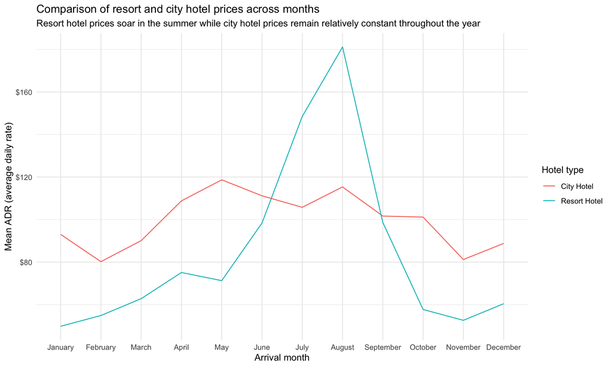

```r
hotels %>%
  group_by(hotel, arrival_date_month) %>%   # group by hotel type and arrival month
  summarise(mean_adr = mean(adr)) %>%       # calculate mean adr for each group
  mutate(arrival_date_month = fct_relevel(arrival_date_month,"January","February","March",
                                          "April","May","June","July",
                                          "August", "September", "October", "November", "December")) %>%
  ggplot(aes(
    x = arrival_date_month,                 # x-axis = arrival_date_month
    y = mean_adr,                           # y-axis = mean_adr calculated above
    group = hotel,                          # group lines by hotel type
    color = hotel)                          # and color by hotel type
    ) +
  geom_line() +                             # use lines to represent data
  theme_minimal() +                         # use a minimal theme
  labs(x = "Arrival month",                 # customize labels
       y = "Mean ADR (average daily rate)",
       title = "Comparison of resort and city hotel prices across months",
       subtitle = "Resort hotel prices soar in the summer while city hotel prices remain relatively constant throughout the year",
       color = "Hotel type")  +
  scale_y_continuous(labels = dollar_format())
```

3. Your final exercise for this section is to manipulate the `hotels` data via dplyr to acheive the following: Create a table that shows, for each month and hotel type, the mean, median, sd, min, and max for the variable `lead_time`.

```r
hotels %>%
  group_by(arrival_date_month, hotel) %>%
  summarize(mean_leadtime = mean(lead_time),
            median_leadtime = median(lead_time),
            sd_leadtime = sd(lead_time),
            min_leadtime = min(lead_time),
            max_leadtime = max(lead_time))
```

```
## # A tibble: 24 × 7
## # Groups:   arrival_date_month [12]
##    arrival_date_mo… hotel mean_leadtime median_leadtime sd_leadtime min_leadtime
##    <chr>            <chr>         <dbl>           <dbl>       <dbl>        <dbl>
##  1 April            City…         111.             93          77.7            4
##  2 April            Reso…          82.4            65          72.5            0
##  3 August           City…         116.             96.5       104.             0
##  4 August           Reso…         105.             89.5        90.1            0
##  5 December         City…          92              41         104.             1
##  6 December         Reso…          58.4            45          52.5            0
##  7 February         City…          47.1            37          44.1            0
##  8 February         Reso…          54.5            24          63.1            0
##  9 January          City…          50.8            27          62.2            3
## 10 January          Reso…          35.1             6          47.2            0
## # … with 14 more rows, and 1 more variable: max_leadtime <dbl>
```

# Brexit Data Viz

In September 2019, YouGov survey asked 1,639 GB adults the following question:

> In hindsight, do you think Britain was right/wrong to vote to leave EU?
> - Right to leave
> - Wrong to leave
> - Don’t know

The data from the survey is in `data/brexit.csv`.

```r
brexit <- read_csv("data/brexit.csv")
```

In the course video we made the following visualization.

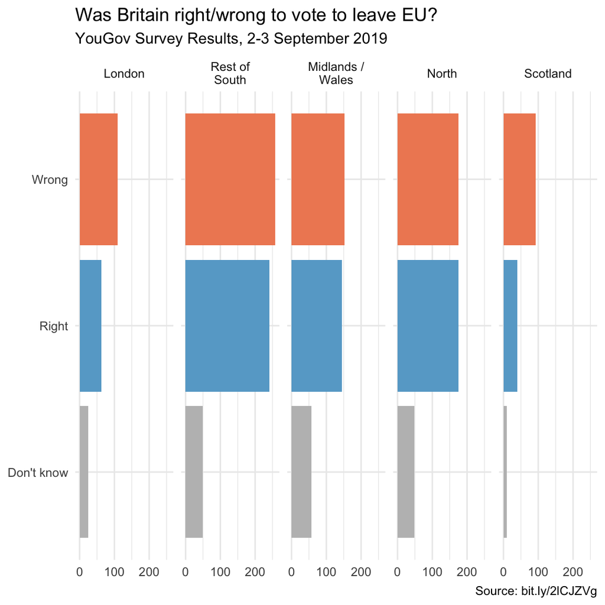

```r
brexit <- brexit %>%
  mutate(
    region = fct_relevel(region, "london", "rest_of_south", "midlands_wales", "north", "scot"),
    region = fct_recode(region, London = "london", `Rest of South` = "rest_of_south", `Midlands / Wales` = "midlands_wales", North = "north", Scotland = "scot")
  )
ggplot(brexit, aes(y = opinion, fill = opinion)) +
  geom_bar() +
  facet_wrap(~region, nrow = 1, labeller = label_wrap_gen(width = 12)) +
  guides(fill = "none") +
  labs(
    title = "Was Britain right/wrong to vote to leave EU?",
    subtitle = "YouGov Survey Results, 2-3 September 2019",
    caption = "Source: bit.ly/2lCJZVg",
    x = NULL, y = NULL
  ) +
  scale_fill_manual(values = c(
    "Wrong" = "#ef8a62",
    "Right" = "#67a9cf",
    "Don't know" = "gray"
  )) +
  theme_minimal()
```

In this lab exercise we tell different stories with the same data.

## Exercise 1 - Free scales

Add `scales = "free_x"` as an argument to the `facet_wrap()` function. How does the visualization change? How is the story this visualization telling different than the story the original plot tells?

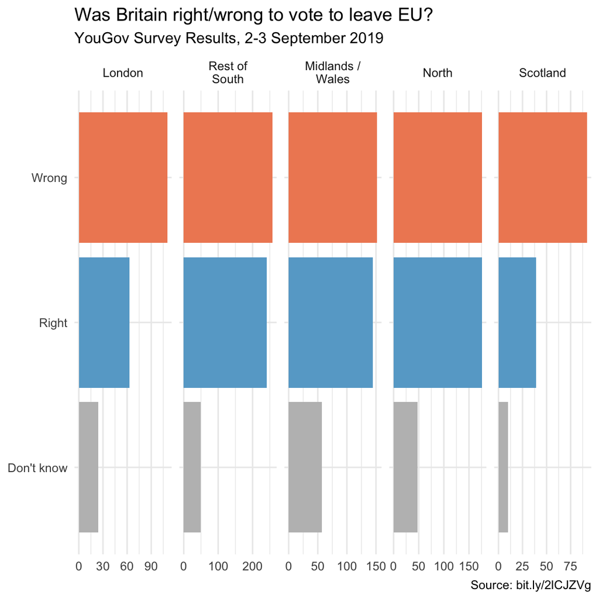

```r
ggplot(brexit, aes(y = opinion, fill = opinion)) +
  geom_bar() +
  facet_wrap(~region,
    nrow = 1, labeller = label_wrap_gen(width = 12),
    scales = "free_x"
  ) +
  guides(fill = "none") +
  labs(
    title = "Was Britain right/wrong to vote to leave EU?",
    subtitle = "YouGov Survey Results, 2-3 September 2019",
    caption = "Source: bit.ly/2lCJZVg",
    x = NULL, y = NULL
  ) +
  scale_fill_manual(values = c(
    "Wrong" = "#ef8a62",
    "Right" = "#67a9cf",
    "Don't know" = "gray"
  )) +
  theme_minimal()
```

**The x-axis is now different for each facet and is based on the specific data limits for that region.**

## Exercise 2 - Comparing proportions across facets

First, create a new object called `brexit_prop`. Assign this object the value of the following: Take the brexit dataset and create a frequency table by region and opinion. Next, group by region before created a new variable called `opinion_prop`. This new variable should be equal to n/sum(n)).

```r
brexit_prop <- brexit %>%
  count(region, opinion) %>%
  group_by(region) %>%
  mutate(opinion_prop=n/sum(n))
```

Now, the below code should run if you created `brexit_prop` correctly. Make sure to add in an appropriate label for the x-axis.

Does the story this visualization tell a different than the original plot tells? **Yes. Now the x-axis is converted into proportions.**

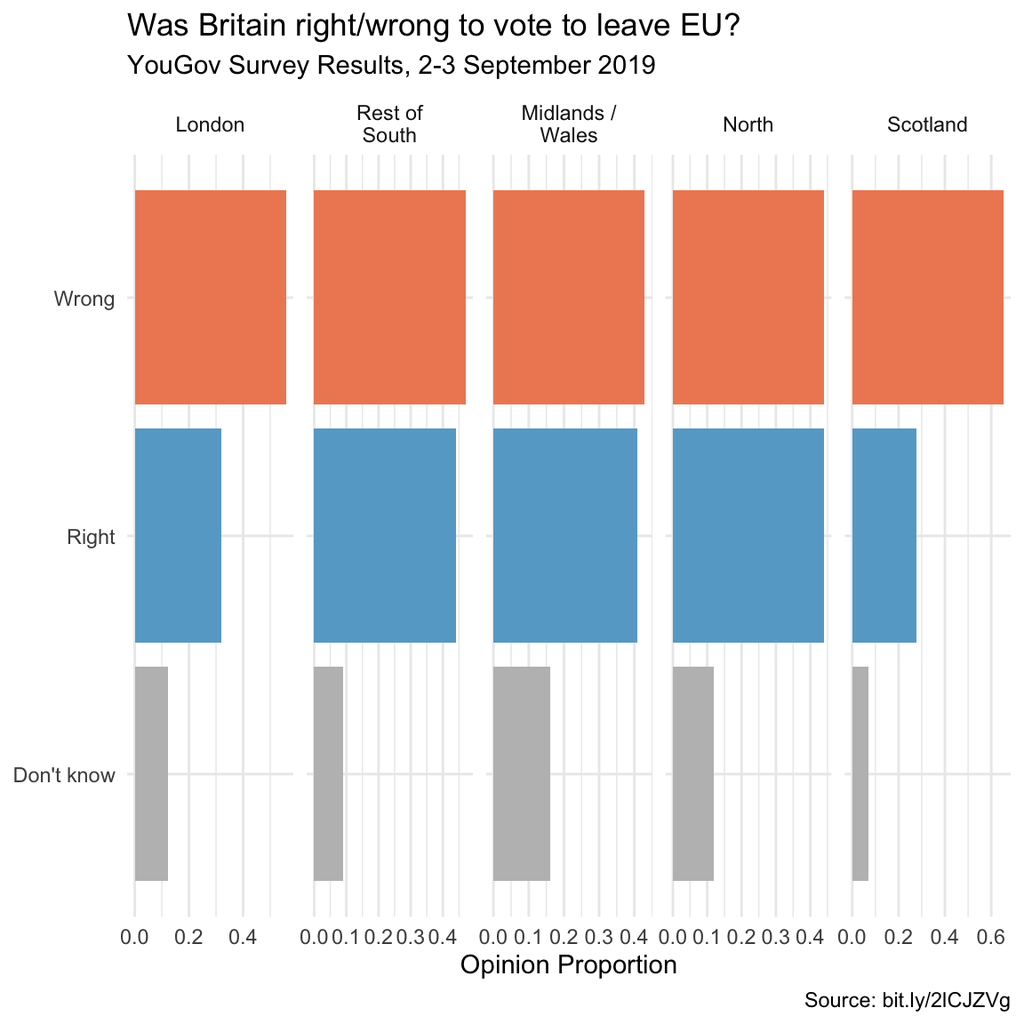

```r
ggplot(brexit_prop, aes(y = opinion, fill = opinion)) +
  stat_summary(aes(x = opinion_prop), geom = "bar") +
  facet_wrap(~region,
    nrow = 1, labeller = label_wrap_gen(width = 12),
    scales = "free_x"
  ) +
  guides(fill = "none") +
  labs(
    title = "Was Britain right/wrong to vote to leave EU?",
    subtitle = "YouGov Survey Results, 2-3 September 2019",
    caption = "Source: bit.ly/2lCJZVg",
    x =  "Opinion Proportion", y = NULL
  ) +
  scale_fill_manual(values = c(
    "Wrong" = "#ef8a62",
    "Right" = "#67a9cf",
    "Don't know" = "gray"
  )) +
  theme_minimal()
```

## Exercise 3 - Comparing proportions of regions per opinion

Recreate the same visualization from the previous exercise, this time filling the bars for opinion proportions for each region, rather than faceting by region and then improve the legend.

Your job is to fill in the blanks in the below code. The goal is to create a plot that is not filled by opinion, but is instead filled by region.

How is the story this visualization telling different than the story the previous plot tells? **With this visualization we see how, for each potential answer, the count breaks down per region.**

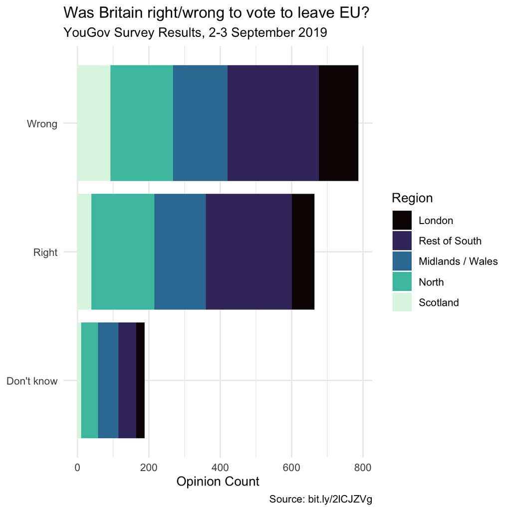

```r
ggplot(brexit, aes(y = opinion, fill = region )) +
  geom_bar() +
  labs(
    title = "Was Britain right/wrong to vote to leave EU?",
    subtitle = "YouGov Survey Results, 2-3 September 2019",
    caption = "Source: bit.ly/2lCJZVg",
    x =  "Opinion Count", y = NULL, fill = "Region"
  ) +
  theme_minimal() +
 scale_fill_viridis(discrete = TRUE, option = "mako")
```

## References

1. Mine Çetinkaya-Rundel; Creator